# BASICS

## Hello Sudarshan

- Its 1st day of Python programming ### LETEX is used for writing mathematical formula
  - $(a+b)^2$ #### here we use start and end with dollar sign and in between write formula

```python
print('hello world')
```

```
hello world
```

## Constants

### Fixed values such as numbers, letters, and strings, are called "Constants" because their value does not change

```python
x=10
print(x)
```

```
10
```

```python
y=20.55
print(y)
```

```
20.55
```

```python
string = "hello world!"
print(string) # string constants use single quotes(') or double quotes(")
```

```
hello world!
```

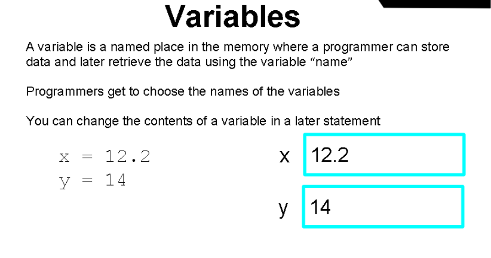

```python
X = 12.2
print(X)
```

```
12.2
```

```python
X = 20
print(X)
```

```
20
```

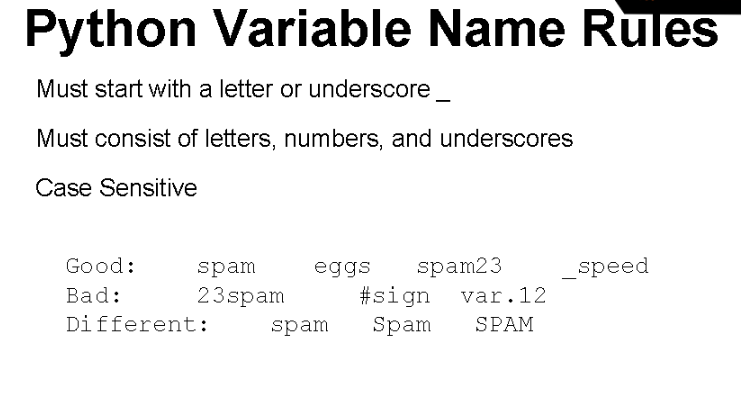

```python
class = a
print(class)# you cannot use reserved words as variables here class is reserved variables
```

```
  File "<ipython-input-7-1dd35638c678>", line 1
    class = a
          ^
SyntaxError: invalid syntax
```

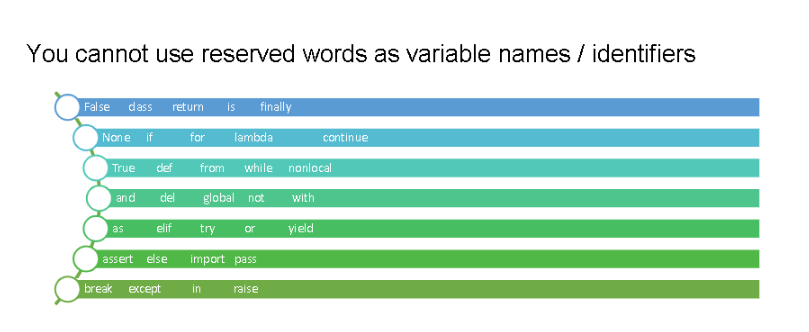

# Arithmaatic Operators

- Addition +
- Substraction -
- Multiplication *
- Division /
- Integer division //
- Modulus %
- Power **

```python
a = 5
b = 6
add = a+b
sub = b-a
mul = a*b
div = a/b
int_dev = b//a
mod = a%b
power = a**2
```

```python
print(add)
print(sub)
print(mul)
print(div)
print(int_dev)
print(mod)
print(power)
```

```
11
1
30
0.8333333333333334
1
5
25
```

```python
2**4
```

```
16
```

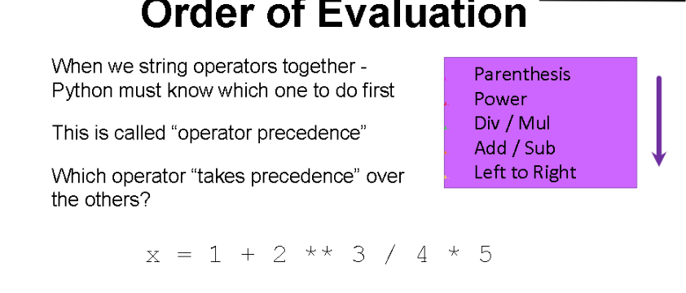

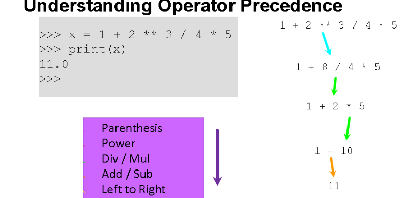

```python
x = 1 +2**3 /4*5
print(x)
```

```
11.0
```

Python knows the difference between an integer number and a string for example "+" means addition

```python
add  = 4 + 4
print(add)# results addition of numbers
```

```
8
```

```python
# where as if add strings result is concateneated
string = "hello" + " world!"
print(string)
```

```
hello world!
```

```python
string1 = "hello "+ 5 # we cannot concatenate number and string
print(string1)
```

```
---------------------------------------------------------------------------
TypeError                                 Traceback (most recent call last)
<ipython-input-14-a67c8b2fd272> in <module>
----> 1 string1 = "hello "+ 5 # we cannot concatenate number and string
      2 print(string1)

TypeError: can only concatenate str (not "int") to str
```

if we want to concatenate then we have to change the type of number to string

```python
string1 = "hello "+ str(5) # number 5 is converted to string type
print(string1)
```

```
hello 5
```

### types

#### numbers have two main types

- integers are whole numbers
- floating point numbers have decimal parts: -2.5, 98.5
- to check we use syntax type()

```python
print(type(5))
print(type(5.5))
```

```
<class 'int'>
<class 'float'>
```

#### type conversion

```python
print(10+50)
print(float(10)+50) # conversion integer 10 to float 10 the result is floating
```

```
60
60.0
```

```python
i = 43
print(type(i))
```

```
<class 'int'>
```

```python
f = float(i)
print(f)
print(type(f))
```

```
43.0
<class 'float'>
```

```python
# integer division produces a floating result
print(16/2)
```

```
8.0
```

#### String conversions

```python
num = '59' # number is string here
print(type(num))
```

```
<class 'str'>
```

```python
print(num+1)
```

```
---------------------------------------------------------------------------
TypeError                                 Traceback (most recent call last)
<ipython-input-22-337215e09d2c> in <module>
----> 1 print(num+1)

TypeError: can only concatenate str (not "int") to str
```

```python
inum = int(num)# coverting to int
print(type(inum))
print(inum+1)
```

```
<class 'int'>
60
```

```python
string = "hello world!"
istring = int(string) # you will get an error if the string does not contain numeric charecters
```

```
---------------------------------------------------------------------------
ValueError                                Traceback (most recent call last)
<ipython-input-24-5db85e42c15d> in <module>
      1 string = "hello world!"
----> 2 istring = int(string) # you will get an error if the string does not contain numeric charecters

ValueError: invalid literal for int() with base 10: 'hello world!'
```

# User Input

- we can instruct python to pause and read data from user using the "input()" function
- the input() function returns a string type

```python
x = input('enter a number:')
print('you have enterd ',x)
```

```
enter a number:5
you have enterd  5
```

```python
print(type(x))
```

```
<class 'str'>
```

```python
x = int(input('enter a number:')) # converting to int type
print('you have enterd ',x)
print(type(x))
```

```
enter a number:5
you have enterd  5
<class 'int'>
```

### To check the memory location we use id() function

```python
print(id(x))
```

```
140715816034832
```

```python
a=10
```

```python
b=10
```

```python
print(id(a),id(b))
```

```
140715816034992 140715816034992
```

- here the variables a and b are assigned with same values therefore memory loacation of the two variables are same

# Basic utility functions

- max()
- min()
- len()

```python
m = max(1,2,3,4,6,7,90,88)
n = min(8,4,5,23,3,22,4,6,6)
l = 'hfnjfgjh'
print(m)
print(n)
print(len(l))
```

```
90
3
8
```

```python
ma = max('suDarshan')
print(ma) # its decide on ascii values
```

```
u
```

```python
# to check ascii values we use chr() function
# In ascii values alphabets are in the range of 65 to 122
for i in range(65,123):
    print(i ,'is ascii value of',chr(i))
```

```
65 is ascii value of A
66 is ascii value of B
67 is ascii value of C
68 is ascii value of D
69 is ascii value of E
70 is ascii value of F
71 is ascii value of G
72 is ascii value of H
73 is ascii value of I
74 is ascii value of J
75 is ascii value of K
76 is ascii value of L
77 is ascii value of M
78 is ascii value of N
79 is ascii value of O
```

[output cut: 43 more lines]

```python
97+26
```

```
123
```

```python
## find area of the square of side 3meters
side = int(input("enter side of the square: "))
area = side * side
print("area of square is: ",area)
```

```
enter side of the square: 5
area of square is:  25
```

```python
import math
```

- This module provides access to the mathematical functions
- https://docs.python.org/3/library/math.html for more details

```python
radius = int(input('enter the radius:'))
area = print('area is',math.pi * math.pow(radius,2))
```

```
enter the radius:5
area is 78.53981633974483
```

```python
a= int(input('enter the length of a '))
b= int(input('enter the length of b '))
c= int(input('enter the length of c '))
s = (a+b+c)/2
print("area of traingle is:",math.sqrt(s*(s-a)*(s-b)*(s-c)))
```

```
enter the length of a 5
enter the length of b 5
enter the length of c 5
area of traingle is: 10.825317547305483
```

# Formating with print()

```python
print("hello")
print("world")
```

```
hello
world
```

```python
print("hello",end='3  4')
print("world")
```

```
hello3  4world
```

```python
x = 10
y =30
total = x + y
print('value of x is',x,'value of y is',y,'value of total is',total)
print('value of x is', x,'value of y is', y,'value of total is',total,sep='\n')
```

```
value of x is 10 value of y is 30 value of total is 40
value of x is
10
value of y is
30
value of total is
40
```

# .format()

```python
a = 10
b = 20
print('the value of a is {} and value of b is {}'.format(a,b))
```

```
the value of a is 10 and value of b is 20
```

```python
a = 5/3
a
```

```
1.6666666666666667
```

```python
print('value of a is: {0:0.2f}'.format(a))
```

```
value of a is: 1.67
```

```python
b = 6/4
print('value of b is: {1:0.2f}, value of a is :{0}'.format(a,b))
```

```
value of b is: 1.50, value of a is :1.6666666666666667
```

# Realational operators

- takes two operands
- Results in boolean value
- Available symbols: >, <, =, <=, >=, !=, ==

```python
a = 10
b = 20
result = a<b
print(result)
```

```
True
```

# logical operators

- Operands and Results are boolean values
- Three operators AND, OR, NOT
- The operators $and$ and $or$ are binary operators ,$not$ is a unary operator

```python
x = 10
y = 20
z = 15

p = x<y and y<z
print(p)
```

```
False
```

```python
a =10
b = 10
p = a is b
print(p)
```

```
True
```

```python
a = True
b =not a
print(b)
```

```
False
```

```python
a= False
b= not a
print(b)
```

```
True
```